# 2.2.2 HT1080 LOY vs sgCTRL — RNA-seq extended (robustness layer)

## 9.7 Per-gene CN delta vs logFC scatter

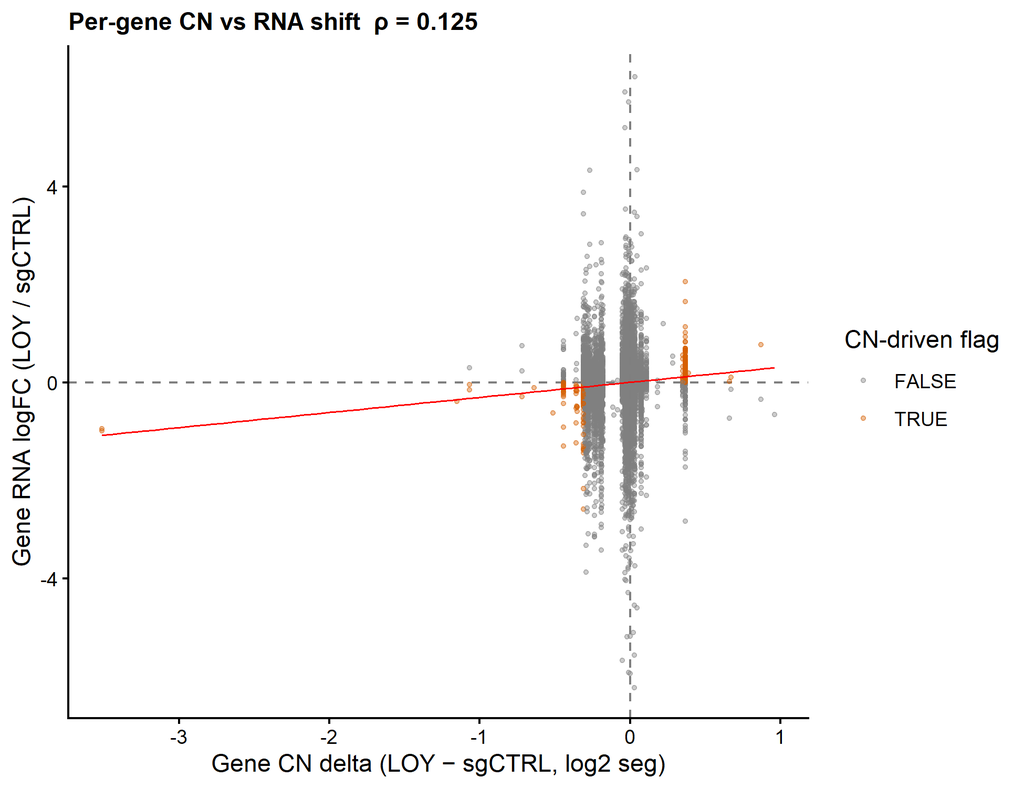

```
## Saved: per_gene_CN_vs_logFC.(png|pdf)  [6.5x5 in]
```

## 9.8 Y-loss confirmation (RNA + lpWGS)

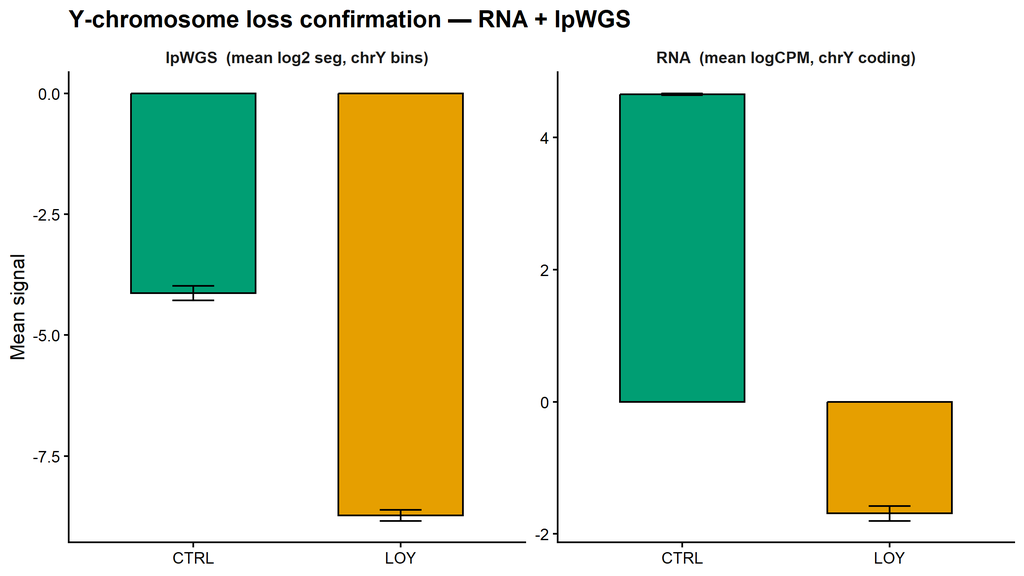

```
## Saved: y_loss_confirmation_RNA_lpWGS.(png|pdf)  [8x4.5 in]
```

## 9.9 CN-flagged DEG sensitivity rerun (by design)

Re-run Hallmark fgsea and decoupleR TF activity with `cn_driven_flag == TRUE` genes removed. Bumps in NES / TF scores that survive this filter are unlikely to be driven by autosomal CN drift. Repeated across all three DE designs — the CN flag set itself comes from the paired DE annotation in §9.4, but the upstream rank vectors differ across designs, so the sensitivity question is worth asking on each.

```
## Genes flagged CN-driven (anchor: paired DE annotation): 343
```

### Paired

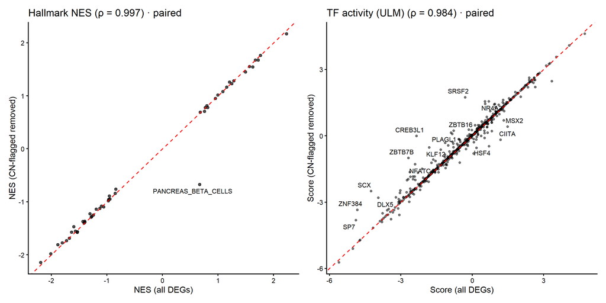

```
## Saved: cn_sensitivity_NES_TF_paired.(png|pdf)  [10x5 in]
```

### Unpaired

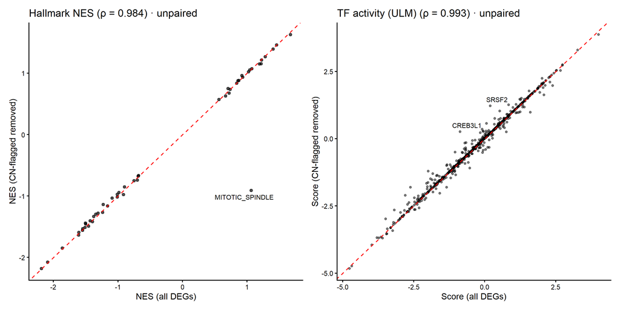

```
## Saved: cn_sensitivity_NES_TF_unpaired.(png|pdf)  [10x5 in]
```

### Pooled

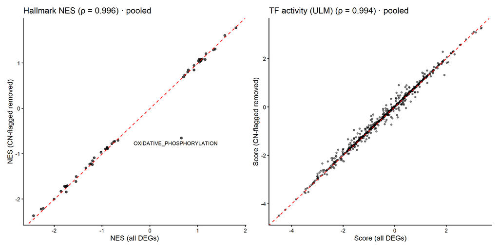

```
## Saved: cn_sensitivity_NES_TF_pooled.(png|pdf)  [10x5 in]
```

# 10. Robustness summary

Per-gene integration across the four statistical pipelines + CN flag + paralog membership. “Confident DEG” = passes ≥ 3 of {voom, voomQW, treat, edgeR-QL} at FDR<0.05 AND is not flagged CN-driven.

```
## Confident DEGs (≥3/4 frameworks, not CN-driven): 1075
```

```
##   up:   463
```

```
##   down: 612
```

```
## Confident + in paralog pair: 0
```

## 10.1 Top confident DEGs

Top-40 confident DEGs

| gene_name | logFC | FDR_voom | FDR_voomQW | FDR_treat | FDR_edgeRQL | n_pass | cn_state_LOY | in_paralog_pair |
| --- | --- | --- | --- | --- | --- | --- | --- | --- |
| MMP1 | -5.92 | 0 | 0 | 0.000 | 0 | 4 | Neutral | FALSE |
| TIMP3 | 1.37 | 0 | 0 | 0.005 | 0 | 4 | Loss | FALSE |
| PAEP | -2.16 | 0 | 0 | 0.002 | 0 | 4 | Neutral | FALSE |
| PARP16 | 1.56 | 0 | 0 | 0.007 | 0 | 4 | Neutral | FALSE |
| NGFR | 1.56 | 0 | 0 | 0.009 | 0 | 4 | Neutral | FALSE |
| MARCKS | -2.43 | 0 | 0 | 0.003 | 0 | 4 | Loss | FALSE |
| ALDH1L2 | -2.01 | 0 | 0 | 0.005 | 0 | 4 | Neutral | FALSE |
| NOX4 | 1.54 | 0 | 0 | 0.010 | 0 | 4 | Neutral | FALSE |
| MYL9 | -1.11 | 0 | 0 | 0.066 | 0 | 3 | Neutral | FALSE |
| ADGRL4 | -1.57 | 0 | 0 | 0.011 | 0 | 4 | Neutral | FALSE |
| AJAP1 | 1.34 | 0 | 0 | 0.024 | 0 | 4 | Neutral | FALSE |
| HECTD4 | 1.02 | 0 | 0 | 0.261 | 0 | 3 | Neutral | FALSE |
| RYR2 | -2.56 | 0 | 0 | 0.004 | 0 | 4 | Neutral | FALSE |
| SDK2 | 3.88 | 0 | 0 | 0.002 | 0 | 4 | Neutral | FALSE |
| CPED1 | -1.04 | 0 | 0 | 0.293 | 0 | 3 | Neutral | FALSE |
| ANOS1 | 1.21 | 0 | 0 | 0.073 | 0 | 3 | Loss | FALSE |
| SPN | 1.34 | 0 | 0 | 0.042 | 0 | 4 | Loss | FALSE |
| OLFML2B | -2.03 | 0 | 0 | 0.009 | 0 | 4 | Neutral | FALSE |
| CECR2 | 1.53 | 0 | 0 | 0.024 | 0 | 4 | Loss | FALSE |
| LGMN | -1.14 | 0 | 0 | 0.154 | 0 | 3 | Neutral | FALSE |
| TP53I11 | 1.78 | 0 | 0 | 0.015 | 0 | 4 | Neutral | FALSE |
| SPTAN1 | -0.91 | 0 | 0 | 1.000 | 0 | 3 | Neutral | FALSE |
| BST2 | -2.19 | 0 | 0 | 0.009 | 0 | 4 | Neutral | FALSE |
| CLSTN2 | -2.26 | 0 | 0 | 0.009 | 0 | 4 | Gain | FALSE |
| UNC5A | 2.30 | 0 | 0 | 0.009 | 0 | 4 | Neutral | FALSE |
| MEGF6 | 1.05 | 0 | 0 | 0.370 | 0 | 3 | Neutral | FALSE |
| ENAH | -0.98 | 0 | 0 | 0.762 | 0 | 3 | Neutral | FALSE |
| WNT7A | 3.54 | 0 | 0 | 0.005 | 0 | 4 | Neutral | FALSE |
| ADGRB1 | 2.04 | 0 | 0 | 0.012 | 0 | 4 | Loss | FALSE |
| TUFT1 | -0.86 | 0 | 0 | 1.000 | 0 | 3 | Neutral | FALSE |
| MAGEA1 | -2.09 | 0 | 0 | 0.012 | 0 | 4 | Loss | FALSE |
| SEPT3 | 2.53 | 0 | 0 | 0.009 | 0 | 4 | NA | FALSE |
| CDH12 | -3.75 | 0 | 0 | 0.005 | 0 | 4 | Neutral | FALSE |
| ZNF528 | -1.83 | 0 | 0 | 0.020 | 0 | 4 | Neutral | FALSE |
| B3GAT1 | 0.99 | 0 | 0 | 0.749 | 0 | 3 | Neutral | FALSE |
| DMKN | 0.80 | 0 | 0 | 1.000 | 0 | 3 | Neutral | FALSE |
| PXDN | -1.24 | 0 | 0 | 0.127 | 0 | 3 | Neutral | FALSE |
| PCOLCE | -1.98 | 0 | 0 | 0.017 | 0 | 4 | Neutral | FALSE |
| CLU | -0.75 | 0 | 0 | 1.000 | 0 | 3 | Loss | FALSE |
| CRISPLD2 | -3.32 | 0 | 0 | 0.007 | 0 | 4 | Loss | FALSE |

## 10.2 Framework agreement plot

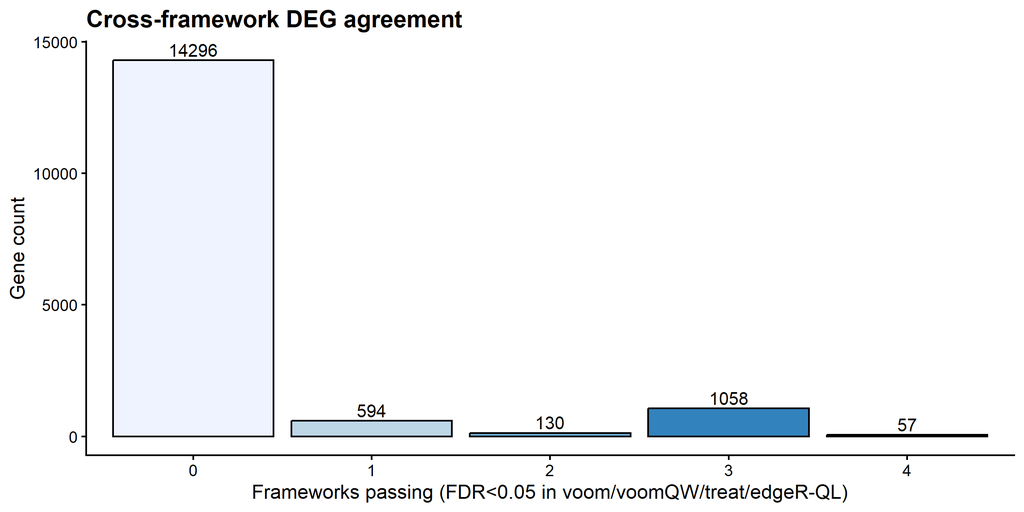

```
## Saved: robust_framework_agreement.(png|pdf)  [8x4 in]
```

## 10.3 Over-representation analysis on confident DEGs

Hypergeometric test (`fgsea::fora`) — does the confident-DEG set (≥3/4 frameworks at FDR<0.05, not CN-driven) overlap pathways more than chance? Up and down are tested separately against the same universe (all tested genes in the working DE).

```
## Universe: 16011 genes
```

```
## Confident up:   463  | down: 612
```

```
##
## === Top 15 Hallmark over-represented in Up-confident DEGs ===
```

| pathway | overlap | size | fold_enrichment | padj |
| --- | --- | --- | --- | --- |
| HALLMARK_ESTROGEN_RESPONSE_LATE | 14 | 167 | 2.90 | 0.0179 |
| HALLMARK_ESTROGEN_RESPONSE_EARLY | 14 | 179 | 2.70 | 0.0180 |
| HALLMARK_MITOTIC_SPINDLE | 14 | 197 | 2.46 | 0.0301 |
| HALLMARK_G2M_CHECKPOINT | 13 | 190 | 2.37 | 0.0339 |
| HALLMARK_APICAL_JUNCTION | 12 | 169 | 2.46 | 0.0339 |
| HALLMARK_E2F_TARGETS | 13 | 195 | 2.31 | 0.0339 |
| HALLMARK_HYPOXIA | 12 | 174 | 2.38 | 0.0339 |
| HALLMARK_EPITHELIAL_MESENCHYMAL_TRANSITION | 11 | 181 | 2.10 | 0.0937 |
| HALLMARK_P53_PATHWAY | 11 | 183 | 2.08 | 0.0937 |
| HALLMARK_MYOGENESIS | 10 | 161 | 2.15 | 0.0937 |
| HALLMARK_TNFA_SIGNALING_VIA_NFKB | 10 | 185 | 1.87 | 0.1842 |
| HALLMARK_GLYCOLYSIS | 10 | 186 | 1.86 | 0.1842 |
| HALLMARK_KRAS_SIGNALING_DN | 7 | 120 | 2.02 | 0.2289 |
| HALLMARK_COAGULATION | 6 | 99 | 2.10 | 0.2402 |
| HALLMARK_APICAL_SURFACE | 3 | 35 | 2.96 | 0.2597 |
| HALLMARK_ALLOGRAFT_REJECTION | 7 | 131 | 1.85 | 0.2597 |
| HALLMARK_KRAS_SIGNALING_UP | 8 | 158 | 1.75 | 0.2597 |

```
##
## === Top 15 Hallmark over-represented in Down-confident DEGs ===
```

| pathway | overlap | size | fold_enrichment | padj |
| --- | --- | --- | --- | --- |
| HALLMARK_EPITHELIAL_MESENCHYMAL_TRANSITION | 27 | 181 | 3.90 | 0.0000 |
| HALLMARK_INTERFERON_GAMMA_RESPONSE | 26 | 172 | 3.95 | 0.0000 |
| HALLMARK_INTERFERON_ALPHA_RESPONSE | 15 | 91 | 4.31 | 0.0000 |
| HALLMARK_APOPTOSIS | 19 | 143 | 3.48 | 0.0000 |
| HALLMARK_COAGULATION | 14 | 99 | 3.70 | 0.0002 |
| HALLMARK_KRAS_SIGNALING_UP | 16 | 158 | 2.65 | 0.0031 |
| HALLMARK_UV_RESPONSE_DN | 13 | 138 | 2.46 | 0.0174 |
| HALLMARK_ANGIOGENESIS | 5 | 29 | 4.51 | 0.0260 |
| HALLMARK_IL6_JAK_STAT3_SIGNALING | 8 | 69 | 3.03 | 0.0260 |
| HALLMARK_APICAL_JUNCTION | 14 | 169 | 2.17 | 0.0261 |
| HALLMARK_IL2_STAT5_SIGNALING | 14 | 170 | 2.15 | 0.0261 |
| HALLMARK_COMPLEMENT | 13 | 163 | 2.09 | 0.0410 |
| HALLMARK_CHOLESTEROL_HOMEOSTASIS | 7 | 68 | 2.69 | 0.0572 |
| HALLMARK_INFLAMMATORY_RESPONSE | 12 | 161 | 1.95 | 0.0745 |
| HALLMARK_ANDROGEN_RESPONSE | 8 | 93 | 2.25 | 0.0861 |

### Hallmark + Reactome dotplot

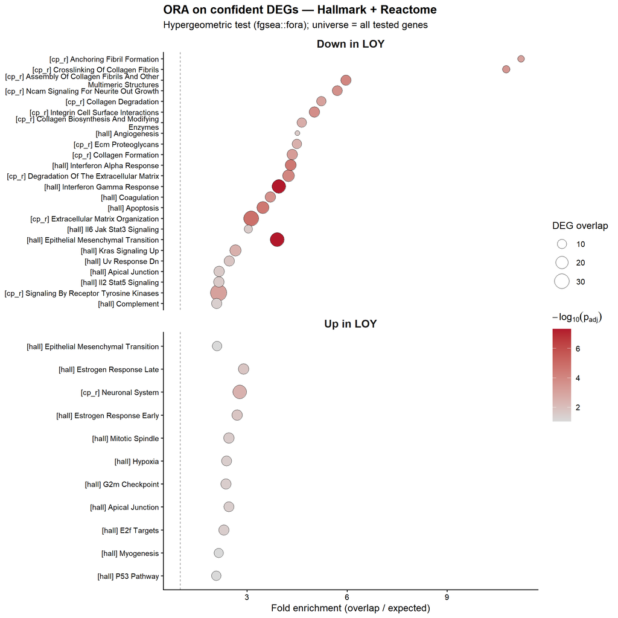

```
## Saved: robust_DEG_ORA_dotplot.(png|pdf)  [8x8 in]
```

### Chromatin / PRC2 ORA (CGP subset)

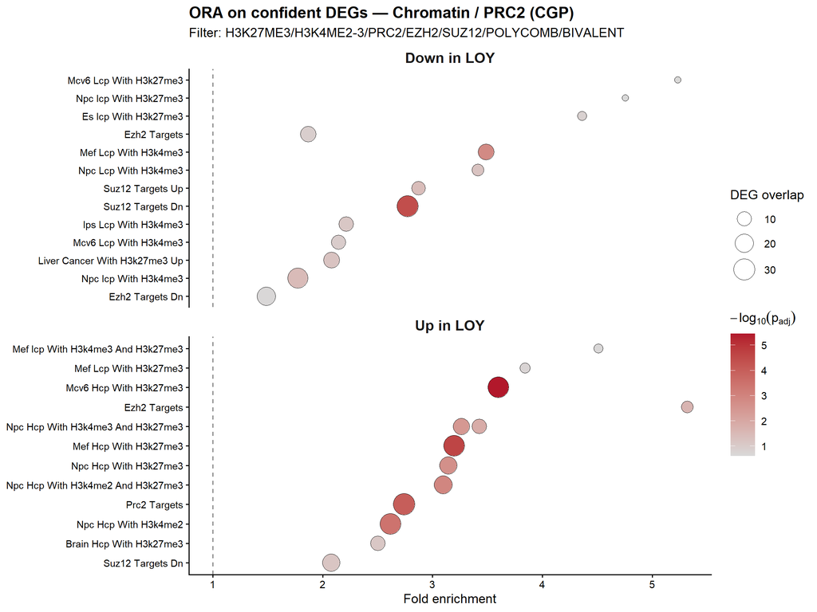

```
## Saved: robust_DEG_ORA_chromatin.(png|pdf)  [8x6 in]
```

## 10.4 Cross-design × cross-framework panel

The §10.1–§10.3 summary above is anchored on the **paired** design (the analysis of record). This sub-section asks the broader question: across all three designs × {voom, treat, edgeR-QL}, how many of the 9 (design × framework) cells does each gene reach FDR<0.05? Genes flagged in ≥6/9 cells AND not CN-driven are the most robust LOY-driven candidates.

```
##
## Cross-design × cross-framework confident DEGs (>=6/9 cells, not CN-driven): 11
```

```
##   up:   9   down: 2
```

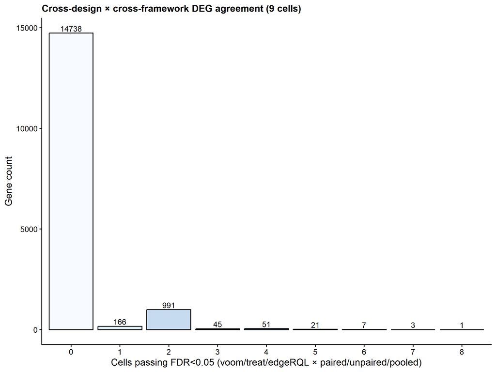

```
## Saved: robust_cross_design_agreement.(png|pdf)  [9x4 in]
```

### Top cross-design confident DEGs

Top-40 confident DEGs across designs (>=6/9 cells, not CN-driven)

| gene_name | logFC | n_pass9 | in_paralog_pair | cn_driven_flag | FDR_voom_paired | FDR_treat_paired | FDR_edgeRQL_paired | FDR_voom_unpaired | FDR_treat_unpaired | FDR_edgeRQL_unpaired | FDR_voom_pooled | FDR_treat_pooled | FDR_edgeRQL_pooled |
| --- | --- | --- | --- | --- | --- | --- | --- | --- | --- | --- | --- | --- | --- |
| SDK2 | 3.88 | 8 | FALSE | FALSE | 0.000 | 0.002 | 0.000 | 0.041 | 0.295 | 0.018 | 0.001 | 0.007 | 0.001 |
| PARP16 | 1.56 | 7 | FALSE | FALSE | 0.000 | 0.007 | 0.000 | 0.041 | 0.421 | 0.020 | 0.044 | 1.000 | 0.044 |
| ADGRB1 | 2.04 | 7 | FALSE | FALSE | 0.000 | 0.012 | 0.000 | 0.041 | 0.295 | 0.020 | 0.025 | 0.796 | 0.042 |
| MAGEA1 | -2.09 | 7 | FALSE | FALSE | 0.000 | 0.012 | 0.000 | 0.041 | 0.295 | 0.018 | 0.015 | 0.183 | 0.005 |
| NGFR | 1.56 | 6 | FALSE | FALSE | 0.000 | 0.009 | 0.000 | 0.072 | 1.000 | 0.046 | 0.015 | 0.467 | 0.010 |
| TP53I11 | 1.78 | 6 | FALSE | FALSE | 0.000 | 0.015 | 0.000 | 0.058 | 0.678 | 0.046 | 0.024 | 0.316 | 0.048 |
| UNC5A | 2.30 | 6 | FALSE | FALSE | 0.000 | 0.009 | 0.000 | 0.058 | 0.359 | 0.024 | 0.015 | 0.183 | 0.009 |
| SEPT3 | 2.53 | 6 | FALSE | FALSE | 0.000 | 0.009 | 0.000 | 0.058 | 0.355 | 0.024 | 0.018 | 0.183 | 0.009 |
| ZNF528 | -1.83 | 6 | FALSE | FALSE | 0.000 | 0.020 | 0.000 | 0.041 | 0.359 | 0.021 | 0.074 | 1.000 | 0.036 |
| DIRAS1 | 2.97 | 6 | FALSE | FALSE | 0.002 | 0.024 | 0.001 | 0.058 | 0.338 | 0.024 | 0.015 | 0.128 | 0.005 |
| ST8SIA3 | 6.24 | 6 | FALSE | FALSE | 0.003 | 0.021 | 0.010 | 0.058 | 0.295 | 0.084 | 0.001 | 0.005 | 0.048 |

# 11. LOY transcriptomics summary table

A consolidated per-gene table of the LOY-vs-sgCTRL effect with per-sample expression. Covers:

- Every **expressed chromosome-Y gene** (post-filter), classified by genomic region as PAR1 / PAR2 / MSY (male-specific Y)
- **PAR1 / PAR2 / MSY signature** rows — mean logCPM across each region per sample, paired-LM test (treatment + passage) on the resulting scores
- **Top-20 up + top-20 down** DEGs from the paired LOY-vs-sgCTRL contrast (FDR<ALPHA, |logFC|>LFC_THR, non-chrY)
- **Genes of interest**: DCC, XIST, and the X-paralogs of each Y gene tracked in §7

Per-sample columns are logCPM (matching how the rest of the report visualises expression). Full CSV (both CPM and logCPM aggregates, per-sample logCPM) lands at `HT1080/DE_extended/ht1080_LOY_transcriptomics_summary.csv`.

## 11.1 PAR1 / PAR2 / MSY / Yp / Yq gene panel

The classifier reuses the PAR coordinate constants defined in §1.4.5 (`PAR1_X_START` etc., `Y_CENTROMERE_MID`). The §11 panel is built from `dge_full_no_yfilter$genes` so the per-sample expression matrix built in §11.2 has matching dimensions — that’s a tighter gene set than §1.4.5’s `y_panel` (which uses the unfiltered `dge0`).

```
## Expressed Y-related genes: 28  [PAR1=13, PAR2=3, MSY=12 (MSY-Yp=3, MSY-Yq=9)]
```

## 11.2 Per-sample expression helper

## 11.3 chrY gene table

PAR1 / PAR2 / MSY genes — paired DE + group-mean expression

| gene_name | region | arm | logFC | FDR | mean_CTRL_logCPM | mean_LOY_logCPM | mean_CTRL_CPM | mean_LOY_CPM |
| --- | --- | --- | --- | --- | --- | --- | --- | --- |
| RPS4Y1 | MSY | Yp | -2.15 | 0.0000 | 6.66 | 4.51 | 101.5 | 23.0 |
| DDX3Y | MSY | Yq | -8.13 | 0.0000 | 6.98 | -1.20 | 126.3 | 0.5 |
| USP9Y | MSY | Yq | -8.14 | 0.0001 | 5.55 | -2.61 | 47.1 | 0.2 |
| KDM5D | MSY | Yq | -7.28 | 0.0001 | 5.61 | -1.73 | 48.9 | 0.3 |
| ZFY | MSY | Yp | -2.29 | 0.0001 | 3.98 | 1.71 | 16.4 | 3.3 |
| EIF1AY | MSY | Yq | -8.57 | 0.0001 | 4.00 | -3.90 | 16.1 | 0.0 |
| NLGN4Y | MSY | Yq | -8.39 | 0.0004 | 3.63 | -4.05 | 12.6 | 0.0 |
| PRORY | MSY | Yq | -8.39 | 0.0008 | 2.39 | -4.57 | 5.2 | 0.0 |
| UTY | MSY | Yq | -6.56 | 0.0020 | 3.10 | -3.38 | 8.6 | 0.1 |
| TTTY10 | MSY | Yq | -4.17 | 0.0223 | -1.71 | -4.57 | 0.3 | 0.0 |
| RBMY2EP | MSY | Yq | -4.31 | 0.0246 | -1.88 | -4.72 | 0.2 | 0.0 |
| LINC00278 | MSY | Yp | -3.63 | 0.0527 | -1.73 | -4.37 | 0.3 | 0.0 |
| CSF2RA | PAR1 | Yp | 1.31 | 0.0005 | 2.99 | 4.28 | 7.9 | 19.6 |
| ZBED1 | PAR1 | Yp | -0.87 | 0.0006 | 5.97 | 5.09 | 62.7 | 34.3 |
| CD99 | PAR1 | Yp | -0.79 | 0.0017 | 8.19 | 7.41 | 294.3 | 171.2 |
| ASMTL | PAR1 | Yp | -0.65 | 0.0030 | 6.07 | 5.43 | 67.3 | 43.0 |
| DHRSX | PAR1 | Yp | -0.67 | 0.0043 | 4.51 | 3.84 | 22.8 | 14.3 |
| SLC25A6 | PAR1 | Yp | -0.50 | 0.0057 | 10.00 | 9.50 | 1025.4 | 732.9 |
| GTPBP6 | PAR1 | Yp | -0.51 | 0.0061 | 6.24 | 5.73 | 75.7 | 53.0 |
| AKAP17A | PAR1 | Yp | -0.50 | 0.0148 | 7.02 | 6.51 | 129.4 | 91.9 |
| IL3RA | PAR1 | Yp | -0.62 | 0.0283 | 3.47 | 2.82 | 11.6 | 7.6 |
| LINC00106 | PAR1 | Yp | -0.59 | 0.1302 | 2.48 | 1.93 | 5.8 | 3.8 |
| P2RY8 | PAR1 | Yp | -1.31 | 0.3781 | -2.65 | -3.59 | 0.2 | 0.1 |
| PLCXD1 | PAR1 | Yp | -0.09 | 0.5991 | 5.58 | 5.48 | 48.3 | 45.7 |
| PPP2R3B | PAR1 | Yp | -0.17 | 0.6687 | 3.07 | 2.88 | 8.4 | 7.5 |
| VAMP7 | PAR2 | Yq | -0.98 | 0.0002 | 6.46 | 5.47 | 88.3 | 44.9 |
| SPRY3 | PAR2 | Yq | -0.39 | 0.3403 | 1.29 | 0.90 | 2.4 | 1.8 |
| IL9R | PAR2 | Yq | -0.95 | 0.3741 | -2.26 | -3.03 | 0.2 | 0.1 |

## 11.4 PAR1 / PAR2 / MSY signature scores

Y-region signatures: PAR1, PAR2, MSY + Yp/Yq arm aggregates (mean region logCPM per sample, paired LM)

| gene_name | n_genes | logFC | PValue | FDR | mean_CTRL_logCPM | mean_LOY_logCPM |
| --- | --- | --- | --- | --- | --- | --- |
| PAR1_signature | 13 | -0.433 | 0.0959 | 0.0959 | 4.84 | 4.41 |
| PAR2_signature | 3 | -0.713 | 0.0053 | 0.0088 | 1.83 | 1.11 |
| MSY_signature | 12 | -5.455 | 0.0009 | 0.0023 | 3.05 | -2.41 |
| Yp_signature | 16 | -0.793 | 0.0099 | 0.0124 | 4.49 | 3.70 |
| Yq_signature | 12 | -5.045 | 0.0005 | 0.0023 | 2.76 | -2.28 |

## 11.4b Per-sample PAR / MSY signature scores

Compact sample-by-region table — the raw per-sample data that feeds the paired-LM tests in §11.4. Each cell is the mean logCPM across the genes in that region for that sample. Useful for spotting per-sample outliers or incomplete LOY (e.g. a “LOY” sample whose MSY mean hasn’t fully collapsed) before reading the summary statistics. Restricted to the LOY-vs-sgCTRL working set (PARENTAL not included; see §1 for the rationale).

Per-sample Y-region mean logCPM (PAR1 / PAR2 / MSY / Yp / Yq)

|  | sample | treatment | passage | PAR1 | PAR2 | MSY | Yp | Yq |
| --- | --- | --- | --- | --- | --- | --- | --- | --- |
| HT1080-CTRL-1 | HT1080-CTRL-1 | CTRL | 1 | 4.96 | 2.11 | 2.99 | 4.59 | 2.77 |
| HT1080-CTRL-2 | HT1080-CTRL-2 | CTRL | 2 | 4.76 | 1.64 | 3.17 | 4.44 | 2.81 |
| HT1080-CTRL-3 | HT1080-CTRL-3 | CTRL | 3 | 4.81 | 1.74 | 2.98 | 4.43 | 2.71 |
| HT1080-LOY-1 | HT1080-LOY-1 | LOY | 1 | 4.29 | 1.36 | -2.15 | 3.67 | -2.05 |
| HT1080-LOY-2 | HT1080-LOY-2 | LOY | 2 | 4.58 | 0.86 | -2.54 | 3.79 | -2.42 |
| HT1080-LOY-3 | HT1080-LOY-3 | LOY | 3 | 4.35 | 1.13 | -2.54 | 3.62 | -2.38 |

```
## Wrote 6-row sample-level PAR/MSY table to ht1080_LOY_sample_level_PAR_MSY.csv
```

## 11.5 Top up + top down DEGs (non-chrY)

Top 20 up + Top 20 down DEGs (paired, FDR<0.05, |logFC|>0.75, non-chrY)

| gene_name | category | logFC | FDR | mean_CTRL_logCPM | mean_LOY_logCPM |
| --- | --- | --- | --- | --- | --- |
| MMP1 | top_down | -5.92 | 0e+00 | 7.97 | 1.93 |
| PAEP | top_down | -2.16 | 1e-04 | 4.66 | 2.50 |
| MYL9 | top_down | -1.11 | 1e-04 | 7.18 | 6.07 |
| MARCKS | top_down | -2.43 | 1e-04 | 4.11 | 1.68 |
| ALDH1L2 | top_down | -2.01 | 1e-04 | 4.66 | 2.64 |
| ADGRL4 | top_down | -1.57 | 1e-04 | 5.59 | 4.00 |
| RYR2 | top_down | -2.56 | 1e-04 | 4.10 | 1.57 |
| COL1A1 | top_down | -1.43 | 2e-04 | 4.87 | 3.41 |
| CPED1 | top_down | -1.04 | 2e-04 | 5.95 | 4.92 |
| OLFML2B | top_down | -2.03 | 2e-04 | 3.53 | 1.46 |
| LGMN | top_down | -1.14 | 3e-04 | 6.47 | 5.33 |
| SPTAN1 | top_down | -0.91 | 3e-04 | 9.13 | 8.22 |
| BST2 | top_down | -2.19 | 3e-04 | 3.09 | 0.93 |
| VAMP7 | top_down | -0.99 | 3e-04 | 6.46 | 5.47 |
| ENAH | top_down | -0.98 | 3e-04 | 6.49 | 5.51 |
| CLSTN2 | top_down | -2.26 | 3e-04 | 3.81 | 1.46 |
| TUFT1 | top_down | -0.86 | 3e-04 | 5.44 | 4.58 |
| MAGEA1 | top_down | -2.09 | 3e-04 | 3.19 | 1.12 |
| CDH12 | top_down | -3.75 | 3e-04 | 2.34 | -1.30 |
| ZNF528 | top_down | -1.83 | 3e-04 | 3.53 | 1.71 |
| PXDN | top_down | -1.24 | 3e-04 | 5.83 | 4.58 |
| TIMP3 | top_up | 1.37 | 0e+00 | 5.64 | 7.02 |
| PARP16 | top_up | 1.56 | 1e-04 | 3.86 | 5.41 |
| NGFR | top_up | 1.56 | 1e-04 | 4.44 | 5.99 |
| NOX4 | top_up | 1.54 | 1e-04 | 4.59 | 6.14 |
| HECTD4 | top_up | 1.02 | 1e-04 | 7.87 | 8.89 |
| AJAP1 | top_up | 1.34 | 1e-04 | 4.25 | 5.60 |
| SDK2 | top_up | 3.88 | 1e-04 | -0.27 | 3.61 |
| ANOS1 | top_up | 1.21 | 2e-04 | 4.48 | 5.67 |
| SPN | top_up | 1.34 | 2e-04 | 4.11 | 5.47 |
| CECR2 | top_up | 1.53 | 3e-04 | 2.74 | 4.28 |
| TP53I11 | top_up | 1.78 | 3e-04 | 2.80 | 4.60 |
| MEGF6 | top_up | 1.05 | 3e-04 | 4.51 | 5.55 |
| UNC5A | top_up | 2.30 | 3e-04 | 0.84 | 3.13 |
| WNT7A | top_up | 3.54 | 3e-04 | -0.69 | 2.69 |
| ADGRB1 | top_up | 2.04 | 3e-04 | 1.37 | 3.41 |
| B3GAT1 | top_up | 0.99 | 3e-04 | 4.75 | 5.74 |
| SEPT3 | top_up | 2.53 | 3e-04 | 0.27 | 2.75 |
| DMKN | top_up | 0.80 | 3e-04 | 6.31 | 7.11 |
| CHRD | top_up | 1.67 | 4e-04 | 2.00 | 3.68 |
| CAPG | top_up | 1.04 | 4e-04 | 5.86 | 6.90 |
| TIE1 | top_up | 0.92 | 4e-04 | 6.33 | 7.24 |

## 11.6 Genes of interest (DCC, XIST, X-paralogs)

Genes of interest (DCC, XIST, X-paralogs)

| gene_name | region | logFC | FDR | mean_CTRL_logCPM | mean_LOY_logCPM |
| --- | --- | --- | --- | --- | --- |
| DCC | chr18 | 1.57 | 0.0292 | -0.38 | 1.31 |
| DDX3X | chrX | 0.03 | 0.8778 | 8.15 | 8.18 |
| EIF1AX | chrX | -0.16 | 0.4612 | 6.38 | 6.21 |
| KDM5C | chrX | -0.04 | 0.8019 | 7.88 | 7.84 |
| KDM6A | chrX | 0.10 | 0.5486 | 5.11 | 5.21 |
| NLGN4X | chrX | 2.17 | 0.1431 | -3.24 | -1.10 |
| PRKX | chrX | 0.10 | 0.4538 | 5.53 | 5.63 |
| RPS4X | chrX | 0.13 | 0.2742 | 10.35 | 10.48 |
| TMSB4X | chrX | -0.13 | 0.3910 | 5.33 | 5.21 |
| USP9X | chrX | -0.09 | 0.5404 | 7.70 | 7.61 |
| XIST | chrX | -2.71 | 0.0434 | -0.86 | -3.36 |
| ZFX | chrX | -0.11 | 0.4913 | 5.15 | 5.02 |

## 11.7 Combined export

```
## Wrote 87 rows to ht1080_LOY_transcriptomics_summary.csv
```